# Summer Academy 2017 Analysis

## By: Andre Williams

### Goal: Provide practical insights and analysis to help Make School

- I'm going to answer 7 questions and do statistical analysis

## Import Packages

```python
import pandas as pd
import numpy as np
import matplotlib.pyplot as plt
%matplotlib inline
import seaborn as sns

df = pd.read_csv('SA-Feedback-Surveys_FINAL/2017/Student Feedback Surveys-Superview.csv')
```

## Basic Analysis

```python
df.head()
```

|  | ID | Location | Track | Week | Rating (Num) | Schedule Pacing |
| --- | --- | --- | --- | --- | --- | --- |
| 0 | 134 | San Francisco | Apps, Explorer | Week 1 | 3 | Just right |
| 1 | 36 | Los Angeles | Apps | Week 1 | 4 | A little too fast |
| 2 | 117 | San Francisco | Games | Week 1 | 4 | Way too slow |
| 3 | 253 | NaN | NaN | Week 2 | 4 | A little too fast |
| 4 | 350 | New York City | Apps, Explorer | Week 1 | 4 | Just right |

```python
df.shape
```

```
(1453, 6)
```

```python
df.info()
```

```
<class 'pandas.core.frame.DataFrame'>
RangeIndex: 1453 entries, 0 to 1452
Data columns (total 6 columns):
 #   Column           Non-Null Count  Dtype
---  ------           --------------  -----
 0   ID               1453 non-null   int64
 1   Location         1406 non-null   object
 2   Track            1406 non-null   object
 3   Week             1453 non-null   object
 4   Rating (Num)     1453 non-null   object
 5   Schedule Pacing  1450 non-null   object
dtypes: int64(1), object(5)
memory usage: 68.2+ KB
```

```python
df.describe()
```

|  | ID |
| --- | --- |
| count | 1453.000000 |
| mean | 759.235375 |
| std | 430.911349 |
| min | 8.000000 |
| 25% | 387.000000 |
| 50% | 764.000000 |
| 75% | 1132.000000 |
| max | 1499.000000 |

## What Was the number of students in each track ?

```python
table = pd.crosstab(df['Track'], df['Week'])
table
```

| Week Track | Week 1 | Week 2 | Week 3 | Week 4 | Week 5 | Week 6 | Week 7 | Week 8 |
| --- | --- | --- | --- | --- | --- | --- | --- | --- |
| Apps | 183 | 176 | 142 | 105 | 101 | 88 | 72 | 4 |
| Apps, Explorer | 42 | 40 | 38 | 34 | 31 | 23 | 16 | 0 |
| Games | 35 | 29 | 36 | 33 | 31 | 21 | 19 | 4 |
| Games, Explorer | 6 | 6 | 7 | 7 | 6 | 6 | 5 | 0 |
| VR | 10 | 10 | 10 | 10 | 7 | 5 | 7 | 1 |

## Where did the majority of the students come from?

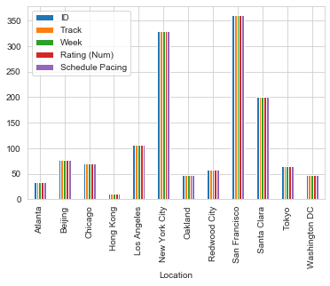

```python
df.groupby(['Location']).count().plot(kind='bar')
```

## What is the total number of students in the program?

```python
apps = dict(pd.crosstab(df['Week'], df['Track']))['Apps'].values
max(apps)
```

```
183
```

```python
explorer_apps = dict(pd.crosstab(df['Week'], df['Track']))['Apps, Explorer'].values
max(explorer_apps)
```

```
42
```

```python
games = dict(pd.crosstab(df['Week'], df['Track']))['Games'].values
max(games)
```

```
36
```

```python
explorer_games = dict(pd.crosstab(df['Week'], df['Track']))['Games, Explorer'].values
max(explorer_games)
```

```
7
```

```python
vr = dict(pd.crosstab(df['Week'], df['Track']))['VR'].values
max(vr)
```

```
10
```

```python
students = {'Apps': 183,
           'Explorer Apps': 42,
           'Games': 36,
           'Explorer Games': 7,
           'VR': 10}

print('The total number of students in the 2017 Academy: ' + str(sum(students.values())))
```

```
The total number of students in the 2017 Academy: 278
```

## How many more promoters are there than detractors across our 2017 data?

### NPS = (Promoters - Detractors) (Promoters + Passives + Detractors)

- Promoter (9 – 10)
- Passive (7 – 8)
- Detractor (1 – 6)

```python
df = df.sort_values("Rating (Num)") # sorts values in descending order
```

```python
df.head()
```

|  | ID | Location | Track | Week | Rating (Num) | Schedule Pacing |
| --- | --- | --- | --- | --- | --- | --- |
| 1310 | 1356 | NaN | NaN | Week 2 | #ERROR! | NaN |
| 1411 | 1458 | NaN | NaN | Week 3 | #ERROR! | NaN |
| 1322 | 1368 | NaN | NaN | Week 3 | #ERROR! | NaN |
| 577 | 608 | NaN | NaN | Week 2 | 0 | Way too fast |
| 1215 | 1261 | New York City | Apps | Week 5 | 0 | A little too fast |

## 3 columns had #Error in our dataset and gets rid of them which changes our response data for Detractors

```python
df = df[~df['Rating (Num)'].str.contains("#")]
```

```python
df.head()
```

|  | ID | Location | Track | Week | Rating (Num) | Schedule Pacing |
| --- | --- | --- | --- | --- | --- | --- |
| 577 | 608 | NaN | NaN | Week 2 | 0 | Way too fast |
| 1215 | 1261 | New York City | Apps | Week 5 | 0 | A little too fast |
| 795 | 833 | New York City | Apps, Explorer | Week 3 | 1 | Way too fast |
| 1451 | 1498 | New York City | Apps, Explorer | Week 7 | 1 | A little too slow |
| 411 | 174 | Chicago | Apps | Week 2 | 10 | A little too fast |

```python
list(df['Rating (Num)'].sort_values(ascending=False).unique())
```

```
['9', '8', '7', '6', '5', '4', '3', '2', '10', '1', '0']
```

## Find Number of Promoters, Passives and Detractors

```python
Promoters = len(df[(df['Rating (Num)'] >= '9')])
print('The number of promoters: ' + str(Promoters))
```

```
The number of promoters: 384
```

```python
Passive = len(df[(df['Rating (Num)'] == '7') | (df['Rating (Num)'] == '8')])
print('The number of passives: ' + str(Passive))
```

```
The number of passives: 569
```

```python
Detractors = len(df[(df['Rating (Num)'] <= '6')])
print('The number of detractors: ' + str(Detractors))
```

```
The number of detractors: 497
```

```python
Answer = Detractors - Promoters
print('There are ' + str(Answer) + ' more detractors responses than promoters')
```

```
There are 113 more detractors responses than promoters
```

## Is there a linear relationship in our data?

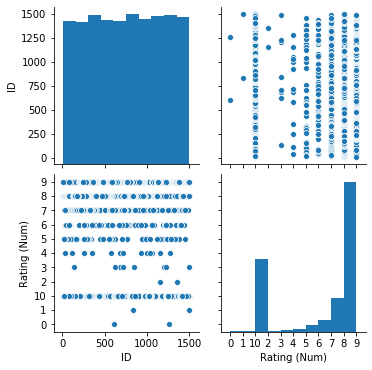

```python
sns.pairplot(df)
```

There is no linear relationship and the data is not normally distributed so we can't use Pearsonr correlation method. We must try a different method to see if a correlation exist in the data because Pearsonr works for linear relationships for continuous variables.

# Non-parametric Methods for Correlation

This is used to find a correlation between categorical non-linearly and non-normally distributed variables.

## Why Spearman's Rank Correlation?

- Use Spearman rank correlation when you have two ranked variables, and you want to see whether the two variables covary; whether, as one variable increases, the other variable tends to increase or decrease

## This is a technique to summarize the strength of data on an ordinal scale. Ordinal variables are variables that are able to be categorized. This conveys the strength of a link between two sets of data.

### 1+ = Perfect Positive Correlation

### 0 = No Correlation

### -1 = Perfect Negative Correlation

```python
import scipy
from scipy.stats import spearmanr
from pylab import rcParams
```

```python
%matplotlib inline
rcParams['figure.figsize']=5, 4
sns.set_style('whitegrid')
```

```python
df.head()
```

|  | ID | Location | Track | Week | Rating (Num) | Schedule Pacing |
| --- | --- | --- | --- | --- | --- | --- |
| 577 | 608 | NaN | NaN | Week 2 | 0 | Way too fast |
| 1215 | 1261 | New York City | Apps | Week 5 | 0 | A little too fast |
| 795 | 833 | New York City | Apps, Explorer | Week 3 | 1 | Way too fast |
| 1451 | 1498 | New York City | Apps, Explorer | Week 7 | 1 | A little too slow |
| 411 | 174 | Chicago | Apps | Week 2 | 10 | A little too fast |

- We have NAN values so lets get rid of them

```python
df.dropna()
```

|  | ID | Location | Track | Week | Rating (Num) | Schedule Pacing |
| --- | --- | --- | --- | --- | --- | --- |
| 1215 | 1261 | New York City | Apps | Week 5 | 0 | A little too fast |
| 795 | 833 | New York City | Apps, Explorer | Week 3 | 1 | Way too fast |
| 1451 | 1498 | New York City | Apps, Explorer | Week 7 | 1 | A little too slow |
| 411 | 174 | Chicago | Apps | Week 2 | 10 | A little too fast |
| 440 | 357 | New York City | Apps | Week 1 | 10 | Just right |
| ... | ... | ... | ... | ... | ... | ... |
| 367 | 477 | Oakland | Apps | Week 3 | 9 | Just right |
| 1091 | 1134 | San Francisco | Apps | Week 6 | 9 | Just right |
| 1092 | 1135 | Chicago | Apps | Week 6 | 9 | Just right |
| 1086 | 1129 | Santa Clara | Apps | Week 6 | 9 | A little too fast |
| 726 | 764 | San Francisco | Apps | Week 4 | 9 | Just right |

1406 rows × 6 columns

```python
location = df['Location']
track = df['Track']
week = df['Week']
rating = df['Rating (Num)']
schedule = df['Schedule Pacing']

spearmanr_coefficient, p_value = spearmanr(week, rating)

print('Spearman Rank Correlation Coefficient: ' + str(spearmanr_coefficient))
```

```
Spearman Rank Correlation Coefficient: -0.014583524323530096
```

```python
spearmanr_coefficient, p_value = spearmanr(week, schedule)

print('Spearman Rank Correlation Coefficient: ' + str(spearmanr_coefficient))
```

```
Spearman Rank Correlation Coefficient: 0.16160209147990992
```

```python
spearmanr_coefficient, p_value = spearmanr(rating, schedule)

print('Spearman Rank Correlation Coefficient: ' + str(spearmanr_coefficient))
```

```
Spearman Rank Correlation Coefficient: -0.06504005159509052
```

## Chi-square test for independence

P_value (probability value) = the probability of obtaining the observed results of a test assuming the null is correct. It is evidence against the null hypothesis.

```python
table = pd.crosstab(rating, schedule)

from scipy.stats import chi2_contingency

chi2, p, dof, expected = chi2_contingency(table.values)
print('Ch-square Statistic %0.3f p_value %0.3f' % (chi2, p))
```

```
Ch-square Statistic 207.070 p_value 0.000
```

Correlated

```python
table = pd.crosstab(week, rating)

from scipy.stats import chi2_contingency

chi2, p, dof, expected = chi2_contingency(table.values)
print('Ch-square Statistic %0.3f p_value %0.3f' % (chi2, p))
```

```
Ch-square Statistic 65.072 p_value 0.644
```

Independent

```python
table = pd.crosstab(df['Week'], df['Schedule Pacing'])

from scipy.stats import chi2_contingency

chi2, p, dof, expected = chi2_contingency(table.values)
print('Ch-square Statistic %0.3f p_value %0.3f' % (chi2, p))
```

```
Ch-square Statistic 92.321 p_value 0.000
```

Correlated

## Conclusion

For these test we need a p_value > .05 in order to conclude that the variables are independent of each other. This means we would fail to reject the null and the variables are independent. If the p_value < .05 then we reject the null hypothesis and conclude that the two variables are correlated and not independent of each other.

## Tried Using the Pearsonr test

```python
from pylab import rcParams
import scipy
from scipy.stats.stats import pearsonr
```

```python
df
```

|  | ID | Location | Track | Week | Rating (Num) | Schedule Pacing |
| --- | --- | --- | --- | --- | --- | --- |
| 577 | 608 | NaN | NaN | Week 2 | 0 | Way too fast |
| 1215 | 1261 | New York City | Apps | Week 5 | 0 | A little too fast |
| 795 | 833 | New York City | Apps, Explorer | Week 3 | 1 | Way too fast |
| 1451 | 1498 | New York City | Apps, Explorer | Week 7 | 1 | A little too slow |
| 411 | 174 | Chicago | Apps | Week 2 | 10 | A little too fast |
| ... | ... | ... | ... | ... | ... | ... |
| 367 | 477 | Oakland | Apps | Week 3 | 9 | Just right |
| 1091 | 1134 | San Francisco | Apps | Week 6 | 9 | Just right |
| 1092 | 1135 | Chicago | Apps | Week 6 | 9 | Just right |
| 1086 | 1129 | Santa Clara | Apps | Week 6 | 9 | A little too fast |
| 726 | 764 | San Francisco | Apps | Week 4 | 9 | Just right |

1450 rows × 6 columns

```python
#df['Week'] = np.where(df['Week'] == 'week 1', 1)
df.Week[df.Week == 'Week 1'] = 1
df.Week[df.Week == 'Week 2'] = 2
df.Week[df.Week == 'Week 3'] = 3
df.Week[df.Week == 'Week 4'] = 4
df.Week[df.Week == 'Week 5'] = 5
df.Week[df.Week == 'Week 6'] = 6
df.Week[df.Week == 'Week 7'] = 7
df.Week[df.Week == 'Week 8'] = 8
df.Week[df.Week == 'Week 9'] = 9
df.Week[df.Week == 'Week 10'] = 10

df
```

[output not shown]

|  | ID | Location | Track | Week | Rating (Num) | Schedule Pacing |
| --- | --- | --- | --- | --- | --- | --- |
| 577 | 608 | NaN | NaN | 2 | 0 | Way too fast |
| 1215 | 1261 | New York City | Apps | 5 | 0 | A little too fast |
| 795 | 833 | New York City | Apps, Explorer | 3 | 1 | Way too fast |
| 1451 | 1498 | New York City | Apps, Explorer | 7 | 1 | A little too slow |
| 411 | 174 | Chicago | Apps | 2 | 10 | A little too fast |
| ... | ... | ... | ... | ... | ... | ... |
| 367 | 477 | Oakland | Apps | 3 | 9 | Just right |
| 1091 | 1134 | San Francisco | Apps | 6 | 9 | Just right |
| 1092 | 1135 | Chicago | Apps | 6 | 9 | Just right |
| 1086 | 1129 | Santa Clara | Apps | 6 | 9 | A little too fast |
| 726 | 764 | San Francisco | Apps | 4 | 9 | Just right |

1450 rows × 6 columns

```python
new = df
new.head()
```

|  | ID | Location | Track | Week | Rating (Num) | Schedule Pacing |
| --- | --- | --- | --- | --- | --- | --- |
| 577 | 608 | NaN | NaN | 2 | 0 | Way too fast |
| 1215 | 1261 | New York City | Apps | 5 | 0 | A little too fast |
| 795 | 833 | New York City | Apps, Explorer | 3 | 1 | Way too fast |
| 1451 | 1498 | New York City | Apps, Explorer | 7 | 1 | A little too slow |
| 411 | 174 | Chicago | Apps | 2 | 10 | A little too fast |

```python
pearsoncorr = new.corr(method='pearson')

pearsoncorr
```

|  | ID |
| --- | --- |
| ID | 1.0 |

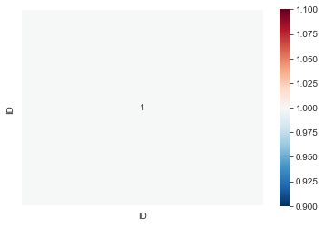

```python
sns.heatmap(pearsoncorr,
           xticklabels=pearsoncorr.columns,
           yticklabels=pearsoncorr.columns,
           cmap='RdBu_r',
           annot=True,
           linewidth=0.5)
```

```python
%matplotlib inline
rcParams['figure.figsize']=5, 4
sns.set_style('whitegrid')
```

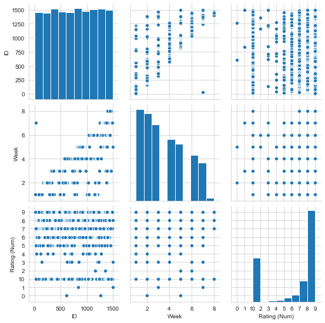

```python
sns.pairplot(df)
```

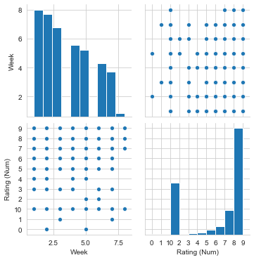

```python
x = df[['Location','Track','Week','Rating (Num)', 'Schedule Pacing']]
sns.pairplot(x)
```

## Students from which location are more likely to give higher ratings?

```python
ratloc = pd.crosstab(df['Location'], df['Rating (Num)'])
ratloc
```

| Rating (Num) Location | 0 | 1 | 10 | 2 | 3 | 4 | 5 | 6 | 7 | 8 | 9 |
| --- | --- | --- | --- | --- | --- | --- | --- | --- | --- | --- | --- |
| Atlanta | 0 | 0 | 14 | 0 | 0 | 0 | 0 | 0 | 1 | 8 | 10 |
| Beijing | 0 | 0 | 27 | 0 | 0 | 0 | 0 | 0 | 6 | 19 | 26 |
| Chicago | 0 | 0 | 17 | 0 | 0 | 0 | 0 | 4 | 12 | 17 | 20 |
| Hong Kong | 0 | 0 | 0 | 0 | 0 | 0 | 1 | 2 | 3 | 4 | 1 |
| Los Angeles | 0 | 0 | 35 | 0 | 0 | 1 | 1 | 3 | 8 | 25 | 33 |
| New York City | 1 | 2 | 84 | 1 | 3 | 3 | 9 | 16 | 38 | 98 | 75 |
| Oakland | 0 | 0 | 12 | 0 | 0 | 0 | 1 | 1 | 9 | 9 | 15 |
| Redwood City | 0 | 0 | 12 | 0 | 0 | 0 | 3 | 2 | 10 | 13 | 18 |
| San Francisco | 0 | 0 | 101 | 1 | 4 | 3 | 6 | 17 | 40 | 95 | 93 |
| Santa Clara | 0 | 0 | 29 | 0 | 0 | 1 | 7 | 5 | 23 | 72 | 64 |
| Tokyo | 0 | 0 | 22 | 0 | 1 | 3 | 2 | 3 | 10 | 13 | 11 |
| Washington DC | 0 | 0 | 10 | 0 | 0 | 0 | 3 | 3 | 7 | 14 | 10 |

# Conclusion

## 8. There is a weak negative correlation between rating and schedule

Advice: Give each student a unique ID to determine more about each individual student. Obtain more data on preferences and student performance to help improve the number of returning students and a stronger curriculum.